# Communicate Data Findings for Ford GoBike System Data

## by (Dhruv Tewari)

## About Data

This data set includes information about individual rides made in a bike-sharing system covering the greater San Francisco Bay area.

This data can also be downloded from :https://www.lyft.com/bikes/bay-wheels/system-data

The data is from January 2017 - March 2020

Each trip is anonymized and includes:

- Trip Duration (seconds)
- Start Time and Date
- End Time and Date
- Start Station ID
- Start Station Name
- Start Station Latitude
- Start Station Longitude
- End Station ID
- End Station Name
- End Station Latitude
- End Station Longitude
- Bike ID
- User Type (Subscriber or Customer – “Subscriber” = Member or “Customer” = Casual)

```python
primary_analysis(Final_df);
```

```
**The dataset has 5275711 rows and 15 columns.**

**The dataset has 7512 duplicate rows.**

**The count of missing values in all variables:**

duration_sec                     0
start_time                       0
end_time                         0
start_station_id            578807
start_station_name          576973
start_station_latitude           0
start_station_longitude          0
end_station_id              580455
end_station_name            578629
end_station_latitude             0
end_station_longitude            0
bike_id                          0
user_type                        0
bike_share_for_all_trip    1148266
rental_access_method       4537015
dtype: int64.

**The information about the dtypes of the variables:**

duration_sec                 int64
start_time                  object
end_time                    object
start_station_id           float64
start_station_name          object
start_station_latitude     float64
start_station_longitude    float64
end_station_id             float64
end_station_name            object
end_station_latitude       float64
end_station_longitude      float64
bike_id                      int64
user_type                   object
bike_share_for_all_trip     object
rental_access_method        object
dtype: object.
```

The above function give us the general ideas of the dataset. It has some duplicates, some missing values and some data types which we need to take care of.

## Feature Engineering

```python
# Creating additional columns of start_month and weekday for analysis purpose
Final_df['start_month'] = Final_df['start_time'].dt.strftime('%m')
Final_df['weekday']     = Final_df['start_time'].dt.strftime('%a')
Final_df['start_hour']  = Final_df['start_time'].dt.strftime('%H')
# Creating a variable for duration in minutes
Final_df['duration_mins']=Final_df['duration_sec']/60
```

## Univariate Exploration

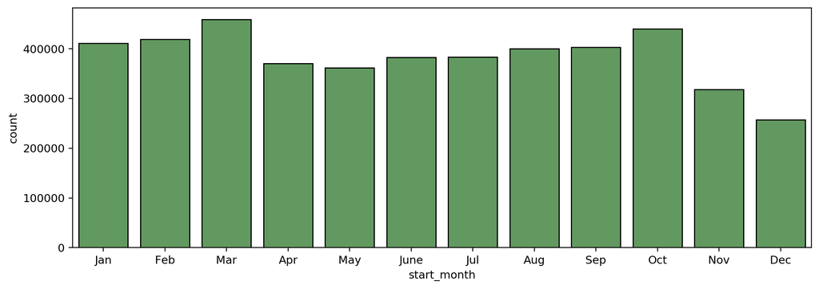

```python
fig, ax = plt.subplots(figsize = (12,4), dpi = 110)
sns.countplot(data= Final_df,x='start_month',color= sns.color_palette()[2],edgecolor = "black");
ax.set(xticklabels=["Jan", "Feb", "Mar", "Apr", "May", "June", "Jul","Aug","Sep","Oct","Nov","Dec"]);
```

The above plot shows us the during the period of Jan,2018 - Mar,2020 which months have highest number of bike sharing. From the analysis it shows the *March* and *October* has the highest number of bike sharing

```
Subscriber    3576322
Customer      1027962
Name: user_type, dtype: int64
```

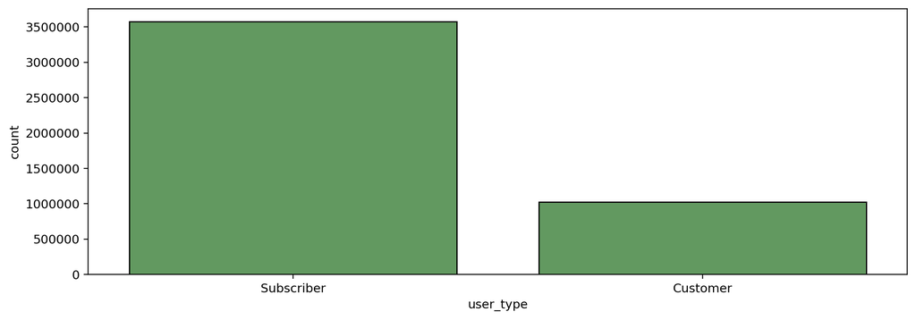

```python
fig, ax = plt.subplots(figsize = (12,4), dpi = 110)
sns.countplot(data= Final_df,x='user_type',color= sns.color_palette()[2],edgecolor = "black");
Final_df['user_type'].value_counts()
```

The plot shows us that the number of subscriber or member for the bike sharing services is far more than the individual customer.

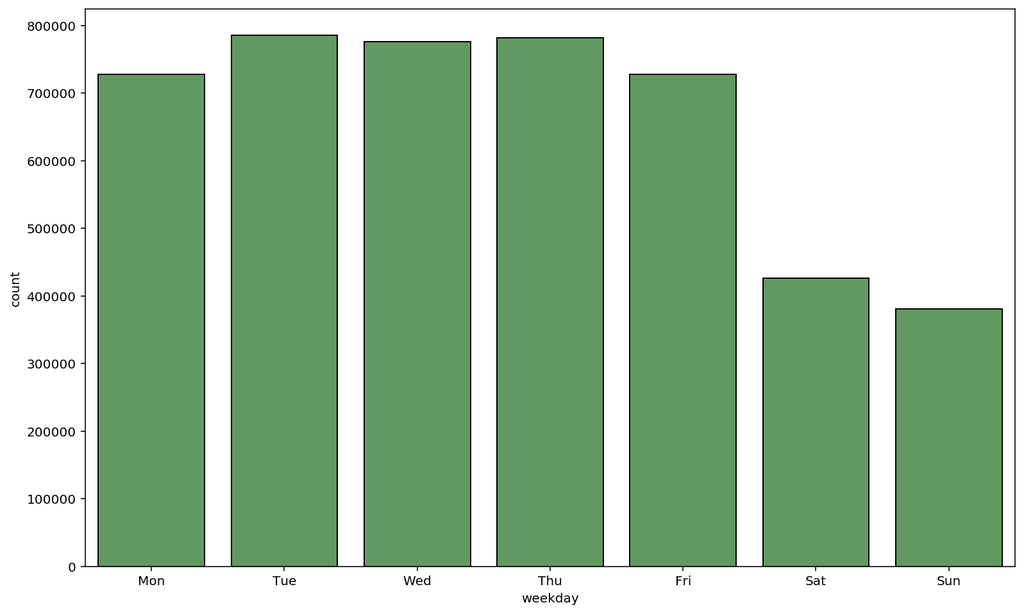

```python
gen_order=['Mon','Tue','Wed','Thu','Fri','Sat','Sun']
sns.countplot(data= Final_df,x='weekday',color= sns.color_palette()[2],order=gen_order,edgecolor = "black");
```

The above plot shows us which days of the week has maximum numbers of bike sharing. From the above plot it is clear that during the weekdays the booking numbers are higher and weekends has lower numbers of booking. This may due to the fact the people are using bikes for there office commute.

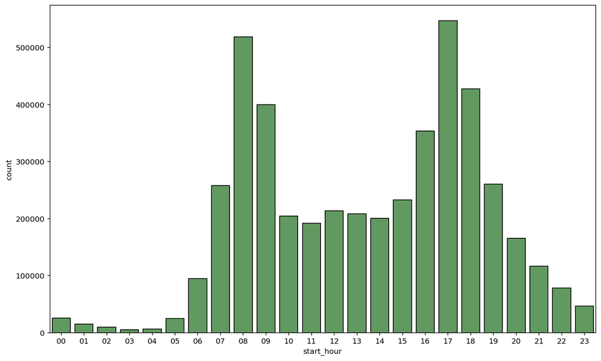

```python
sns.countplot(data= Final_df,x='start_hour',color= sns.color_palette()[2],edgecolor = "black");
```

The above plot shows the distriubtion of the bike sharing during the 24-hrs of time throughout the time duration of analysis. From the graph it is clear that during the office commute time the bike sharing has maximum counts.

```
The minimum duration for which the bike is booked is:    1.0 min
The maximum duration for which the bike is booked is:    23.99 hrs
```

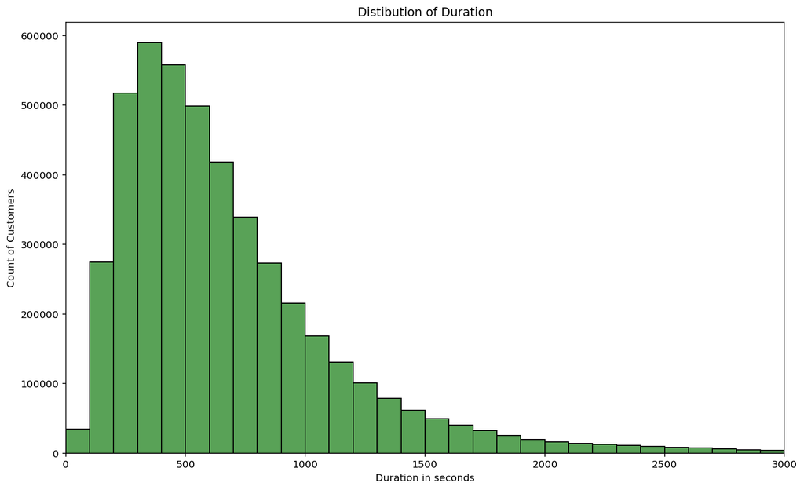

```python
# Calculating
Min_duration = Final_df['duration_sec'].min()/60
Max_duration= Final_df['duration_sec'].max()/(60*60)
print("The minimum duration for which the bike is booked is:    {} min".format(Min_duration))
print("The maximum duration for which the bike is booked is:    {:.2f} hrs".format(Max_duration))
bins=np.arange(0,Final_df['duration_sec'].max()+5,100)
plt.hist(data=Final_df,x='duration_sec',bins=bins,color= sns.color_palette()[2],edgecolor = "black");
plt.xlabel('Duration in seconds')
plt.ylabel('Count of Customers')
plt.title('Distibution of Duration')
plt.xlim(0,3000);
```

From the above distribution we found out the minimum duration for which the bike is booked is *1.0 min* and maximum duration for which the bike is booked is 24 hrs. Also, the booking duration for 300-500 seconds has the maximum counts.

## Bivariate Exploration

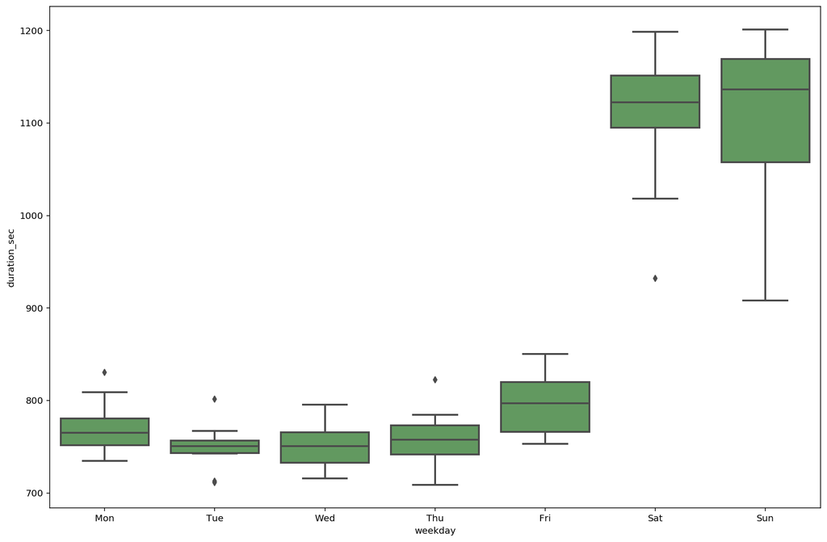

```python
fig, ax = plt.subplots(figsize = (15,10))
sns.boxplot(x = "weekday", y = "duration_sec",order=gen_order,color= sns.color_palette()[2],
             data = Final_df.groupby(["weekday", "start_month"],
                                                                   as_index = False).mean());
```

The above box plot shows the distribution of the duration of the time for which the bike is booked and from the plot it is very interesting to know that however there are less numbers of booking during weekends but the duration of the time for which the bikes are book are maximum during the weekends.

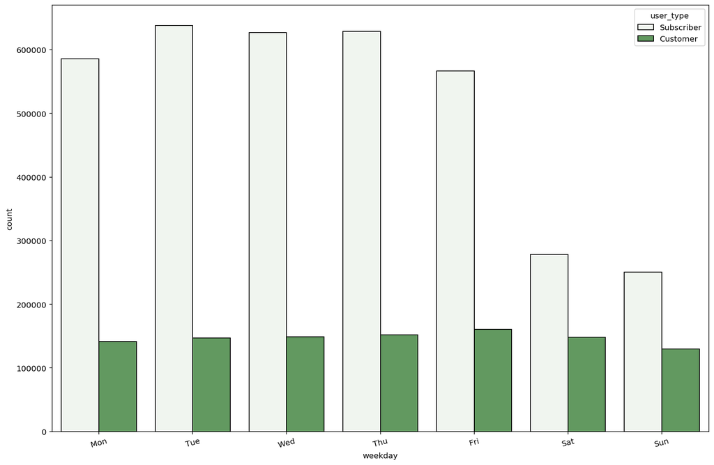

```python
# for cluster bar chart we need to just add one more parameter
fig, ax = plt.subplots(figsize = (15,10))
sns.countplot(data=Final_df,x='weekday',hue='user_type',order=gen_order,edgecolor = "black",color= sns.color_palette()[2])
plt.xticks(rotation=15);
```

The above plot shows the distribution of the customers and subscribers during days of the week. We can see some variation in the number of counts in bike sharing for Subscribers. However, the variance in the counts for the customers are remaining constant.

## Multivariate Exploration

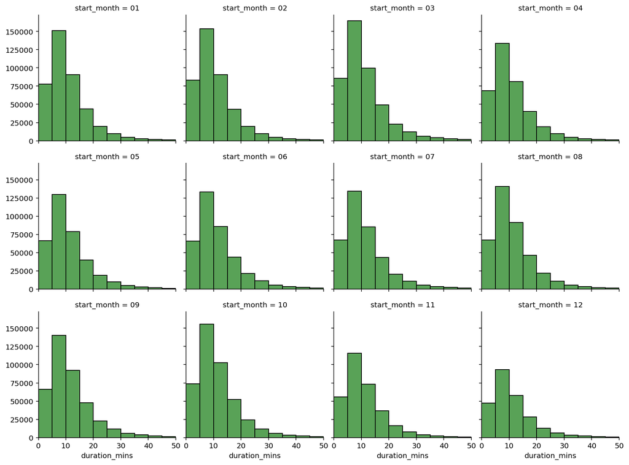

```python
bins=np.arange(0,Final_df['duration_sec'].max()+5,5)
g= sns.FacetGrid(data=Final_df,col='start_month',col_wrap= 4);
g.map(plt.hist,'duration_mins',bins=bins,edgecolor = "black",color= sns.color_palette()[2])# What kind of plot we want to plot
plt.xlim(0,50);
```

The above graphs shows the distribution of booking durations of bike in minutes with respect to each month of the year.